# Bellabeat Case Study using R programming

Igor Remesz

**email:** igor.remesz@gmail.com

**last updated:** 03.08.2021

# **Introduction**

**The Mission**

Bellabeat’s mission is to deliver wellness products designed for women. It is targeted for young to middle-aged women who live active lifestyles, care about their health as well as make informed choices every day in terms of their diet, workout routine, meditation, and hydration.

**The Products**

Bellabeat’s product line includes a Bellabeat app, a Bellabeat Leaf wellness tracker, a smartwatch, a smart water bottle, and a subscription-based membership program for users.

**The Task & The Dataset**

My job, as an imaginary junior data analyst, is to provide primary and secondary stakeholders within the company with insightful recommendations regarding one product in their line of wellness products. For this case study I have decided to go with the smartwatch and have been tasked to use a Kaggle dataset for FitBit Fitness Tracker (under CC0: Public Domain license) as a benchmark since it is also a smartwatch and collects similar data to Bellabeat’s smartwatch.

My job is to give sound advice and recommend improvements to the current business plan by applying a data-driven decision-making framework.

This process will require me to **ask** the right questions, **prepare** the dataset, and choose crucial metrics to analyze. Next, I am going to **clean** and **analyze** the clean dataset. Afterward, I am going to **visualize** and finally **share** my recommendation for further actions to stakeholders.

**The People**

**Primary stakeholders** include: Urška Sršen: Bellabeat’s co-founder and Chief Creative Officer. Sando Mur: Mathematician and Bellabeat’s co-founder; a key member of the Bellabeat executive team.

**Secondary stakeholders**: Bellabeat marketing analytics team (this is the team I am a “part of”).

## **Step 1: Assessing data’s integrity and veryfing if it ROCCC(s)**

The dataset I am using as a benchmark comes from Kaggle and can be downloaded here. It contains information about FitBit tracker, a benchmark device for Bellabeat’s Time.

Is the dataset:

- *Reliable?*

The sample is limited to only 30 original users. It doesn’t contain any sensitive data about users’ gender, location, or age. The dataset was originally collected from a random group of FitBit users. They all willingly shared their data with the authors of FitBit Fitness Tracker Data. My initial impression is that a larger sample is needed to achieve reliable results. Perhaps even 10x larger than FitBit Fitness Tracker Data.

- *Original?*

Yes, we can locate the original public data.

- *Comprehensive?*

Yes, it contains more than a solid amount of .csv files with numerous metrics to pick for analysis.

- *Current?*

The original data comes from 2016. That might be problematic and might not fully represent trends of using wearable fitness devices.

- *Cited?*

Yes, the source, creator and terms of use are easily available.

In this analysis, I am going to use Spreadsheets to identify primary datasets. Next, I am going to use R programming to analyze the data further and visualize it.

## **Step 2: Ask**

First of all, I want to ask the following question:

What do you **see** when you look at Bellabeat’s smartwatch? I would like to visually compare Bellabeat’s Time smartwatch with benchmark FitBit Tracker smart device.

This is Bellabeat’s Time:

[figure not shown]

Image Source

Here’s FitBit’s tracker:

[figure not shown]

Image Source

One can easily observe that Bellabeat’s goal is not only to make useful products but also make them stylish and beautiful. Bellabeat’s Time can be easily matched with a variety of outfits and doesn’t look like wearable technology, on the face of it. That is contrary to FitBit’s appearance, which to my mind looks more like an extension of a smartphone on users’ wrists.

As I have already established the mission statement and business task are quite clear. In terms of the framework I am going to split the process into separate phases: **Ask, Prepare, Process, Analyze, Share & Act.**

I am going to find answers for the following questions:

- Are our datasets error and duplicate free?
- How can I ensure data integrity?
- What can be done to ethically store, process and analyze data?
- What are some trends to be found in datasets to help Bellabeat achieve their business goal?
- How can my insights drive business decisions?
- What are the limitations of data in this case?

## **Step 3: Prepare**

The dataset I have downloaded from Kaggle includes both wide and long data. It consists of 18 different .csv files in total, each offering in-depth metrics about users’ heart rate, sleep monitoring, calories burned, the minute-level output of physical activity & the intensity of physical activity, just to name a few. This dataset does not include users’ private data, such as Name, Surname, Gender, or Address.

Since my task is to focus on only one product from Bellabeat’s product line, I have picked Bellabeat’s smartwatch, *Time*. Apart from telling time it tracks customers’ activity and sleep patterns and feeds that information to a dedicated app that shares insights with its owner.

I am going to analyze the following datasets:

- **dailyActivity_merged.csv (merged data of calories, intensities, and steps)**
- **sleepDay_merged.csv**
- **weightLogInfo_merged.csv**

Firstly, I would like to address the possible limitations of data. As I have mentioned before, the 30 users sample size might be a great underrepresentation of Fitbit users I am using as a benchmark for my analysis. Furthermore, original data is 5 years old and trends of using wearable smart fitness devices may have changed.

```
=COUNTIF(D:D; ">50")
```

Thank concludes the Spreadsheets part of analysis.

## **Step 4: Rstudio Setup**

Frist, I am going to install all the necessary packages required to complete the task at hand.

```
setwd("C:\\..\\Fitabase Data 4.12.16-5.12.16")

install.packages("tidyverse")
install.packages("kableExtra")
install.packages("scales")
install.packages("highcharter")
install.packages("lubridate")
install.packages("dplyr")
install.packages("here")
install.packages("gridExtra")

library(tidyverse)
library(kableExtra)
library(scales)
library(highcharter)
library(lubridate)
library(dplyr)
library(here)
library(gridExtra)

daily_activity <- read_csv("C:\\..\\Fitabase Data 4.12.16-5.12.16\\dailyActivity_merged.csv")
sleep <- read_csv("C:\\..\\Fitabase Data 4.12.16-5.12.16\\sleepDay_merged.csv")
weight <- read_csv("C:\\..\\Fitabase Data 4.12.16-5.12.16\\weightLogInfo_merged.csv")
```

Let’s take a look if it was imported properly.

```
head(daily_activity)
head(sleep)
head(weight)
```

Now, time to explore the datasets. Let’s first look at the number of participants in each dataset.

```
n_distinct(daily_activity$Id)
# 33
n_distinct(sleep$Id)
# 24
n_distinct(weight$Id)
# 8
```

```
nrow(daily_activity)
# 940
nrow(sleep)
# 413
nrow(weight)
# 67
```

**Inference**

We can quickly observe that:

- there are more than 30 distinct Ids (or ‘Users’) in the *daily_activity* set
- *sleep* set has a tad fewer than 30 unique Ids
- *weight* has just 8 unique Ids
- Why is that? Is it on users’ behalf to log information to the FitBit tracker?
- Why are there so few unique Ids in the *weight* set? Could it mean that FitBit users are not that keen on sharing their weight data versus activity data?
- Perhaps it is an issue of UX? How could we encourage users to distribute their attention equally among various smartwatch features?

Nevertheless, let’s look at our datasets again, in full capacity.

```
View(daily_activity)
View(sleep)
View(weight)
```

We can observe that the *weight* set actually contains a Boolean type data about manual reporting. It will be possible to differenciate between auto reports ad manual reports.

## Step 5: Process

**daily_activity**

- Remove missing values
- Remove duplicates
- Rename ActivityDate to **Date**
- Change Date column from character to date type
- Create new column with **Weekdays**
- Create new column **TotalActiveMinutes** summing up all active minutes

```
#Duplicates
sum(duplicated(daily_activity))

#Missing values
sum(is.na(daily_activity))

#Rename ActivityDate to Date
colnames(daily_activity)[colnames(daily_activity) == "ActivityDate"] <- "Date"

#Format character to date type
daily_activity$Date <-  as.Date(daily_activity$Date,format='%m/%d/%Y')

#Add new column Weekdays
daily_activity$Weekdays <- wday(daily_activity$Date, label = TRUE, abbr = FALSE)

#Add new column with total active minutes
daily_activity2 <- daily_activity %>%
  mutate(TotalActiveMinutes = VeryActiveMinutes + FairlyActiveMinutes + LightlyActiveMinutes)

#Confirm changes
str(daily_activity2)
View(daily_activity2)
```

No duplicates found, no missing values found. This operation was successful.

**sleep**

- Remove missing values
- Remove duplicates
- Rename SleepDay to **Date**
- Change Date column from character to date type
- Create a new column with **Weekdays**

```
#Duplicates
sum(duplicated(sleep))

#Missing values
sum(is.na(sleep))

#Rename ActivityDate to Date
colnames(sleep)[colnames(sleep) == "SleepDay"] <- "Date"

#Format character to date type
sleep$Date <- as.Date(sleep$Date, format = '%m/%d/%Y')

#Add new column Weekdays
sleep$Weekdays <- wday(sleep$Date, label = TRUE, abbr = FALSE)


#Confirm changes
str(sleep)
View(sleep)
```

**weight**

- Remove missing values
- Remove duplicates
- Separate date and time from Date column
- Change Date column from character to date type
- Create a new column with **Weekdays**

```
#Duplicates
sum(duplicated(weight))

#Missing values
sum(is.na(weight$WeightPounds))

#Separate date and time
weight2 <- weight %>%
  separate(Date, into=c("Date","Time"), sep=" ",remove =TRUE )

#Format column to date type
weight2$Date <- as.Date(weight2$Date,format='%m/%d/%Y')

#Add new column Weekdays
weight2$Weekdays<- wday(weight2$Date, label = TRUE, abbr = FALSE)

#Confirm changes
str(weight2)
View(weight2)
```

No duplicates nor missing values - another successful operation.

**Merging the datasets**

I am going to combine my cleaned datasets into one, big, beautiful dataset using Id and Dates

```
merged_final_df <- merge(merge(daily_activity2, sleep, by = c('Id', 'Date'), all = TRUE), weight2, by = c('Id', 'Date'), all = TRUE)
```

Checking the data type and statistical summary.

```
str(merged_final_df)

summary(merged_final_df)
```

**Summary of cleaned data**

Daily activity

```
daily_activity2 %>%
  select(TotalSteps,
         TotalDistance,
         Calories,
         VeryActiveMinutes,
         FairlyActiveMinutes,
         LightlyActiveMinutes) %>%
  summary()
```

Sleep

```
sleep %>%
  select(TotalSleepRecords,
         TotalMinutesAsleep,
         TotalTimeInBed) %>%
  summary()
```

Weight

```
weight2 %>%
  select(WeightKg,
         BMI,
         IsManualReport) %>%
  summary()
```

**First Conclusions**

Looking at the merged dataset, we can see that data was logged for 31 days. Comparing *SedentaryMinutes* Max. value of 1440.0 to *LightlyActive* and *VeryActive Max*. values - 518.0 and 210.0 respectively - we can deduce that most users are neither professional sportspeople nor lead very active lifestyles. Moreover, if we look at the *Mean WeightKg = 72.04*, one might assume that the majority of users are women.

This is because, according to [this](https://www.cdc.gov/nchs/data/nhsr/nhsr122-508.pdf) CDC report, in the years 2015-2016 (the year the original dataset was collected) women aged 20 and more had a mean weight in KG of **77.3** (vs **72.04KG** in FitBit users) in the United States. It might mean that said users do not need diet recommendations.

Furthermore, looking at the *TotalMinutesAsleep* column in my merged dataset we can see that the mean amount of minutes asleep = 419.5 which is equal to roughly 7 hours of sleep. According to the [U.S. Department of Health and Human Services](https://health.gov/myhealthfinder/topics/everyday-healthy-living/mental-health-and-relationships/get-enough-sleep) “*Most adults need 7 or more hours of good-quality sleep on a regular schedule each night. Getting enough sleep isn’t only about total hours of sleep. It’s also important to get good-quality sleep on a regular schedule, so you feel rested when you wake up.*”

Additionally, the mean amount of *TotalSteps* is roughly 7.7k steps per day which is less than enough for a healthy adult, according to the [CDC’s report](https://www.cdc.gov/diabetes/prevention/pdf/postcurriculum_session8.pdf). The goal should be 10k per day.

**Initial Inference**

Bellabeat might want to implement a feature that notifies users if they don’t sleep enough or encourage them to walk more.

## Step 6: Analyze

**Plotting Auto vs Manual reports of weight data**

It could be interesting to discover how dedicated are FitBit users when it comes to reporting their weight. The following plot shows the the distribution of Auto Report vs. Manual Report by type:

```
report_method_name <- c("Manual Report","Auto Report")
report_method_T_F <- c(length(which(weight$IsManualReport =="TRUE")),length(which(weight$IsManualReport =="FALSE")))
manual_report_or_not <- data.frame(report_method_name,report_method_T_F)
```

```
ggplot(manual_report_or_not, aes(report_method_name,report_method_T_F)) +
  geom_bar(stat= "identity", fill="blue")+
  geom_text(aes(label=report_method_T_F), vjust=3, color="white", size=5)+
  labs(title="Weight Log Methods by Types",  x= "Weight Log Methods", y="Number of Records")
```

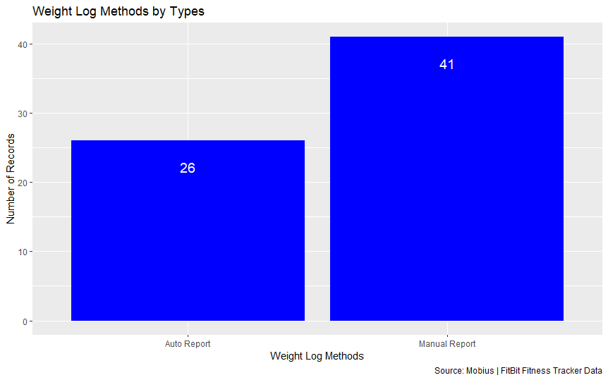

**Inference**

Looking at this data viz we can observe that even though there are only 8 distinct Ids in the *weight* set, 61.1% of reports are manual. It might be that users need more encouragement to report their weight.

**Plotting calories burned vs. steps taken**

```
merged_activity_sleep_weight %>%
  group_by(TotalSteps, Calories) %>%
  ggplot(aes(x = TotalSteps, y = Calories, color = Calories)) +
  geom_point() +
  geom_smooth() +
  theme_bw() +
  theme(legend.position = c(.05, .8),
        legend.spacing.y = unit(1, "mm"),
        panel.border = element_rect(colour = "black", fill=NA),
        legend.background = element_blank(),
        legend.box.background = element_rect(colour = "black")) +
  labs(title = 'Calories burned by total steps taken',
       y = 'Calories',
       x = 'Total Steps')
```

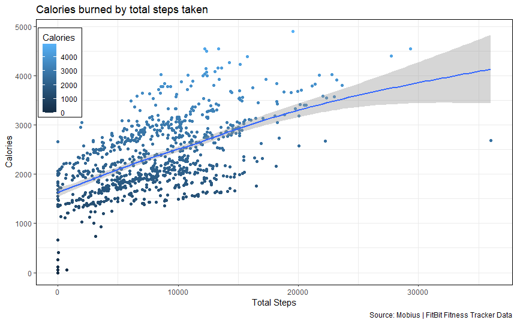

Unsurprisingly, there is a positive correlation - the more steps you take, the more calories you burn. To be even more confident about this conclusion, we can check the correlation between these two variables using the *Pearson Correlation Coefficient*.

```
cor.test(merged_final_df$TotalSteps, merged_final_df$Calories, method = 'pearson', conf.level = 0.95)
```

[output not shown]

As we can see, the correlation between the variables is almost 0.6. It means that there is a strong relationship between them.

**Plotting activity distribution among users**

To discover an activity trend, I am going to plot a wheel chart to showcase activity distribution among users:

```
daily_activity2 %>%
  select(VeryActiveMinutes,
         FairlyActiveMinutes,
         LightlyActiveMinutes,
         SedentaryMinutes) %>%
  summarise(across(everything(), list(sum))) %>%
  gather(active_level, minutes) %>%
  mutate(active_level = factor(active_level,
                               labels = c('Moderate Activity','Light Activity',
                                          'Sedentary','Heavy Activity'))) %>%
  hchart('pie', hcaes(x = active_level, y = minutes)) %>%
  hc_title(text = "Distribution of daily activity level in minutes") %>%
  hc_tooltip(pointFormat = "<b>Value:</b> {point.y} <br>
                 <b>Percentage</b> {point.percentage:,.2f}%")
```

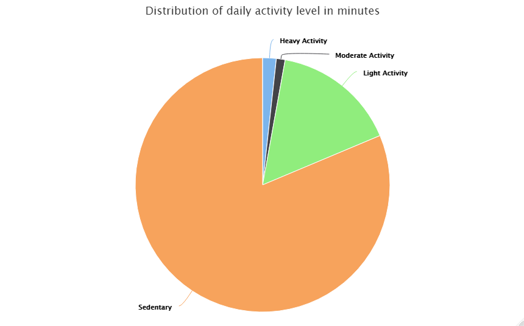

**Activity Distribution**

- *Sedentary*: **81.33%**
- *Light Activity*: **15.82%**
- *Moderate Activity*: **1.11%**
- *Heavy Activity*: **1.74%**

**Inference**

It seems like Fitbit users are mostly inactive people. Maybe they wear them purely for their aesthetics?

**Plotting sleep distribution**

Now, to visualize my previous assumption about FitBit’s users and their sleep patterns and habits, I am going to plot their sleep distribution to showcase whether or not they get enough sleep.

```
sleep %>%
  select(TotalMinutesAsleep) %>%
  drop_na () %>%
  mutate(sleep_quality = ifelse(TotalMinutesAsleep <= 420, 'Less than 7h',
                         ifelse(TotalMinutesAsleep <= 540, '7h to 9h',
                                'More than 9h'))) %>%
  mutate(sleep_quality = factor(sleep_quality,
                                levels = c('Less than 7h', '7h to 9h', 'More than 9h'))) %>%
  ggplot(aes(x = TotalMinutesAsleep, fill = sleep_quality)) +
  geom_histogram(position = 'dodge', bins = 30) +
  theme_bw() +
  theme(legend.position = c(.8, .8),
        legend.title = element_blank(),
        legend.spacing.y = unit(0, "mm"),
        panel.border = element_rect(colour = "black", fill = NA),
        legend.background = element_blank(),
        legend.box.background = element_rect(colour = "black")) +
  labs(title = "Sleep distribution",
       x = "Time slept (minutes)",
       y = "Count")
```

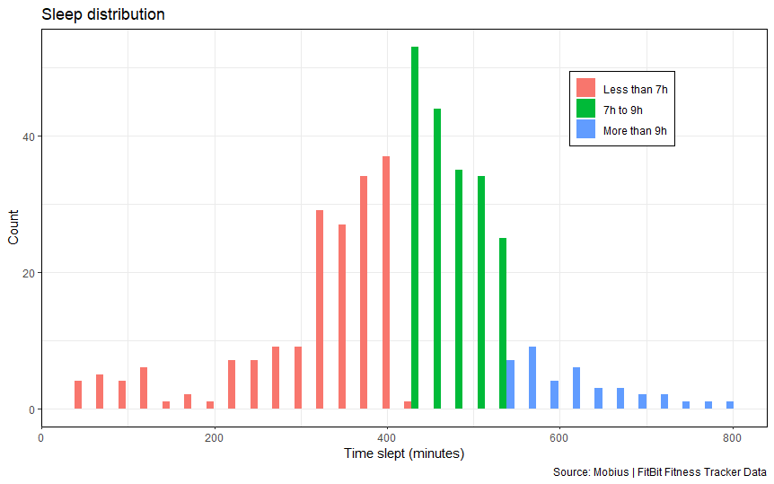

**Relationship between sleep and distance covered**

I want to find out what’s the relationship between how much FitBit users walk and how well they sleep. If you walk more, do you also sleep more? If you do cover less ground on foot does it mean that you sleep better? Let’s investigate:

```
merged_final_df %>%
  select(Id, TotalDistance, TotalMinutesAsleep) %>%
  group_by(Id) %>%
  summarise_all(list(~mean(., na.rm=TRUE))) %>%
  drop_na() %>%
  mutate(Id = factor(Id)) %>%
  ggplot() +
  geom_bar(aes(x = Id, y = TotalDistance), stat = "identity", fill = 'lightblue', color = 'black') +
  geom_point(aes(x = Id, y = TotalMinutesAsleep/60), color = 'red') +
  geom_segment(aes(x = Id, xend = Id, y = 0, yend = TotalMinutesAsleep/60), color = 'red', group = 1) +
  theme_minimal() +
  scale_y_continuous(limits = c(0, 12), name = "Total Distance",
                     sec.axis = sec_axis(~.*60, name = "Sleep in minutes")) +
  theme(axis.text.x = element_text(angle = 45, hjust = 1)) +
  theme(axis.title.y.right = element_text(color = "red"),
        axis.ticks.y.right = element_line(color = "red"),
        axis.text.y.right = element_text(color = "red")) +
  labs(title = "Average distance vs average sleep by user",
       x = "Users")
```

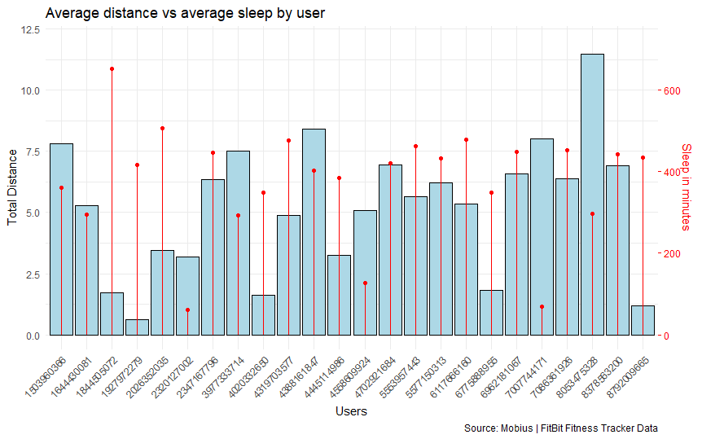

**Inference**

Looking at the plot above, one cannot in my opinion say, that there is a clear relationship between the distance you travel on foot per day and sleep pattern. That is, on average, at least.

**Plotting sleep vs minutes in bed, to find out if the difference between actual sleep and minutes spent in bed**

I want to find out if our users like to spend more time in their beds than necessary. First, I want to learn what’s the difference between the time users spend sleeping and time they spend in their beds:

```
sleep_activity <- sleep %>%
  mutate(TimeAwakeInBed = TotalTimeInBed - TotalMinutesAsleep)
```

Now, let’s plot the difference:

```
ggplot(sleep_activity, aes(x=TimeAwakeInBed)) +
  geom_histogram(aes(y=..density..), binwidth=30, alpha=0.6)+
  geom_density(alpha=0.2, fill="blue") +
  geom_vline(aes(xintercept=mean(TimeAwakeInBed)), color="red", linetype="dashed") +
  geom_vline(aes(xintercept=max(TimeAwakeInBed)), color="red", linetype="dashed") +
  annotate(geom="text", x=39 + 55, y = 0.02, size = 7, label = "mean = 39") +
  annotate(geom="text", x=371 - 50, y = 0.02, size = 7, label = "max = 371") +
  labs(x= "Time Awake in Bed", y="Density")
```

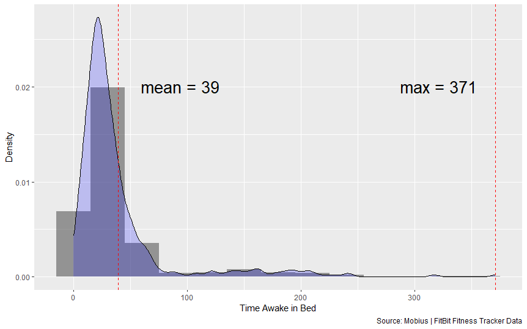

Looking at this data viz, we can observe that FitBit users spend arguably too much time in bed. They spend on average 39 minutes awake in bed, which is not that bad, frankly, but could be improved. A tiny portion spends even more time, sometimes more than 200 minutes.

**How many minutes during weekdays users are active?**

To answer that question, I am going to plot a different activity charts during weekdays:

```
average_very_active_minutes <- daily_activity2 %>%
  group_by(Weekdays) %>%
  summarise_at(vars(VeryActiveMinutes),
               list(VeryActiveMinutes = mean))

average_fairly_active_minutes <- daily_activity2 %>%
  group_by(Weekdays) %>%
  summarise_at(vars(FairlyActiveMinutes),
               list(FairlyActiveMinutes = mean))

average_lightly_active_minutes <- daily_activity2 %>%
  group_by(Weekdays) %>%
  summarise_at(vars(LightlyActiveMinutes),
               list(LightlyActiveMinutes = mean))

average_total_active_minutes <- daily_activity2 %>%
  group_by(Weekdays) %>%
  summarise_at(vars(TotalActiveMinutes),
               list(TotalActiveMinutes = mean))

average_activity_minutes <- merge(average_very_active_minutes,average_fairly_active_minutes,by=c("Weekdays"))

average_activity_minutes1 <- merge(average_activity_minutes,average_lightly_active_minutes, by=c("Weekdays"))


average_activity_minutes %>%
  ggplot(aes(x="Weekdays",y = average_activity_minutes,fill=type)) + geom_boxplot(outlier.colour = 'red', outlier.shape = 8)+
  theme(legend.position = 'none') +
  stat_summary(fun=mean, geom="point", shape=21, size=4)


very_active_chart <- ggplot(average_activity_minutes1, aes(x=Weekdays,y=VeryActiveMinutes, group=1))+
  geom_line(color = "green1")+
  labs(title="Average Very Active Minutes by Weekdays", x= "Weekdays", y="Daily Very Active Minutes")+
  geom_text(aes(label=round(VeryActiveMinutes, digits=0), hjust=-0.75, vjust=0.2),size=3)+
  theme(plot.title = element_text(size=11), text = element_text(size=10), axis.text.x = element_text(angle=35, hjust=1))

fairly_active_chart <- ggplot(average_activity_minutes1, aes(x=Weekdays, y=FairlyActiveMinutes, group=1))+
  geom_line(color = "blue")+
  labs(title="Average Fairly Active Minutes by Weekdays", x= "Weekdays", y="Daily Fairly Active Minutes")+
  geom_text(aes(label=round(FairlyActiveMinutes, digits=0), hjust=-.75, vjust=0.75),size=3.0)+
  theme(plot.title = element_text(size=11), text = element_text(size=10), axis.text.x = element_text(angle=35, hjust=1))


lightly_active_chart <- ggplot(average_activity_minutes1, aes(x=Weekdays, y=LightlyActiveMinutes, group=1))+
  geom_line(color = "purple")+
  labs(title="Average Lightly Active Minutes by Weekdays", x= "Weekdays", y="Daily Lightly Active Minutes")+
  geom_text(aes(label=round(LightlyActiveMinutes, digits=0), hjust=-0.5, vjust=0.75),size=3)+
  theme(plot.title = element_text(size=11), text = element_text(size=10), axis.text.x = element_text(angle=35, hjust=1))

average_daily_total <- ggplot(average_total_active_minutes, aes(x=Weekdays, y=TotalActiveMinutes, group=1))+
  geom_line(color = "orange1")+
  labs(title="Average Total Active Minutes by Weekdays", x= "Weekdays", y="Total Active Minues")+
  geom_text(aes(label=round(TotalActiveMinutes, digits=0), hjust=-0.1, vjust=0.9),size=3)+
  theme(plot.title = element_text(size=11), text = element_text(size=10), axis.text.x = element_text(angle=35, hjust=1))

grid.arrange(very_active_chart,fairly_active_chart,lightly_active_chart,average_daily_total, nrow=2)
```

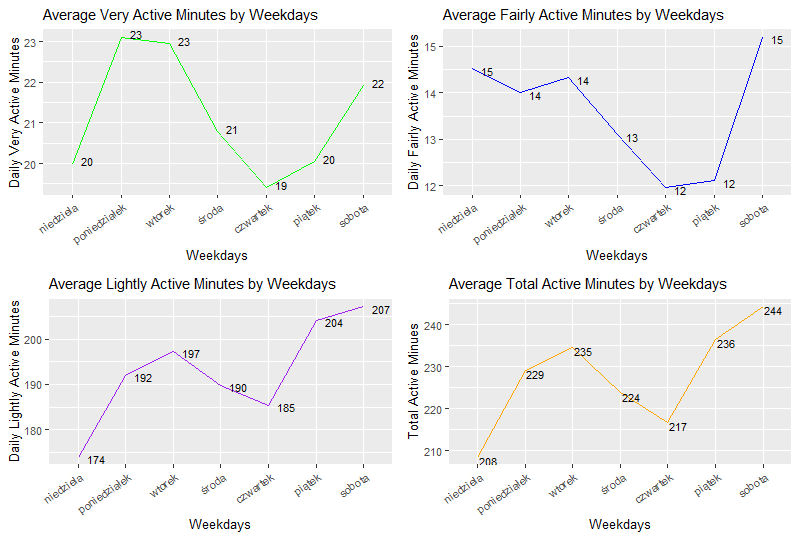

## Step 7: Share

Additionally

- Unsurprisingly, the more you walk, the more calories one burns through the day.
- There is no correlation between the distance users travel on foot and the amount of sleep they get.
- Unfortunately, the *weight* dataset is too scarce to analyze and draw conclusions from it properly. Collecting a larger dataset is needed.
- Overall integrity of dataset could be increased, for example, by collecting data from a larger sample of the user population.

## Step 8: Act

In terms of a recommendation for Bellabeat regarding their business model and their smartwatch, Time, Bellabeat could:

- Keep making a stylish product since benchmark analysis shows that most users use it as a trendy gadget rather than a fitness device
- Keep developing the UX for an app that pairs with Time smartwatch. Better UX might encourage users to manually report their weight data. This could be rewarded by introducing an “Achievements” feature where a users can keep track of their progress if they are aiming to loose weight or get more fit in general
- Consider introducing features and non-intrusive notifications to remind users about healthy sleep patterns, activity time, or to get out of bed as soon as they wake up
- Recommend health and fitness articles via their Bellabeat app to motivate users
- Send reminders to encourage healthy habits and routines before and after sleep hours and further promote mindfulness
- Send notifications to encourage users to walk more, at least try to achieve the recommended 10k steps per day.
- Introduce a feature that allows users to set goals based on Bellabeats’ recommendations in terms of sleep, calories burned, and activity time
- It would be interesting to learn if users have trouble falling asleep or trouble getting out of bed. How can Bellabeat obtain such data?
- I believe it would be exciting if the Bellabeat app could connect with the smartphone camera and match steps taken with photos taken on a particular day. It could create a bond between users and their Bellabeat device/software.

### Thak you for your time :)